# outlier제거(IQR1.5기준) 및 지역별, 연도별 평단가 분산분석 + 다중회귀분석(종속변수 SalePrice)

Author

2023-2학기 통계자료분석 1조 김재현

Published

December 6, 2023

Modified

December 23, 2023

## 데이터 불러오기 및 변수 정리

```r
# 데이터 불러오기

rawdata = read_excel("./Team_Assignment/Reyeme2.xls")
data1 = as.data.frame(rawdata)
data1$FirstDate = as.Date(as.numeric(as.character(data1$FirstDate)),origin="1899-12-30")
data1$RC = as.factor(data1$RC)
data1$Area = as.factor(data1$Area)
```

```r
# 데이터 변수 클래스 확인

str(data1)
```

```
'data.frame':   456 obs. of  17 variables:
 $ Address  : chr  "73 Allston St" "239 Allston St" "83 Amory St" "107 Antrim St" ...
 $ Unit     : chr  "1" "2" "3" "1" ...
 $ Area     : Factor w/ 16 levels "AG","AH","C",..: 4 4 9 9 9 9 9 9 9 9 ...
 $ AreaCode : num  4 4 9 9 9 9 9 9 9 9 ...
 $ Price1   : num  109000 127000 123000 219000 199000 ...
 $ Price2   : num  109000 127000 100000 210000 189000 ...
 $ SalePrice: num  106000 125000 95000 206000 175000 ...
 $ FirstDate: Date, format: "1993-07-17" "1993-08-21" ...
 $ CloseDate: POSIXct, format: "1993-10-22" "1993-10-22" ...
 $ Days     : num  97 62 208 159 110 116 160 80 157 123 ...
 $ Interior : num  834 850 730 1460 1630 ...
 $ Bed      : num  2 2 2 3 4 2 2 3 3 3 ...
 $ Bath     : num  1 1 1 2 1 1 1 1 1 1 ...
 $ Rooms    : num  4 5 4 6 8 6 6 5 6 6 ...
 $ Condo    : num  70 100 185 100 50 100 100 163 150 100 ...
 $ Tax      : num  490 923 575 1582 1659 ...
 $ RC       : Factor w/ 2 levels "0","1": 1 2 1 2 2 2 2 1 2 2 ...
```

```r
# 결측값 존재 확인

sum(is.na(data1))
```

```
[1] 9
```

**Note**

결측값 9개 존재.

```r
# 결측값 있는 행 확인

which(rowSums(is.na(data1)) > 0)
```

```
[1]  27 181 248 254 350 368 383 454 455
```

**Note**

결측값 중 한개를 제외하곤 모두 UNIT 열 값이다. UNIT는 건물내 특정 주거공간을 나타내는 호수(ex 101호, 102호)이다. Reyem Affiar가 구매하려는 건물의 UNIT는 주어져있지 않기 때문에 Reyem Affiar가 구매하려는 건물 가격을 추정하는데에 UNIT 변수는 사용하지 않을 것으로 예상한다. 나머지 한개의 결측값은 First Date에서 나타났으며, 254행에 있다. FirstDate열은 사용할 예정이므로 254행만 제외한다.

```r
#결측값 있는 행 중 254행 제거

data2 = data1[-254,]
```

```r
# data3 = data2의 Address 열 나누기

data3 <- separate(data2, Address, into = c("AddressNo", "AddressName", "Street"), sep = " ")
data3$AddressNo = as.factor(data3$AddressNo)
data3$AddressName = as.factor(data3$AddressName)
data3$Street = as.factor(data3$Street)
```

```r
#| label: First Date를 연 월 일로 열 나누기
# First Date를 연 월 일로 열 나누기

data4 <- separate(data3, FirstDate, into = c("YearF", "MonthF", "DateF"), sep = "-")
data4$YearF = as.factor(data4$YearF)
data4$MonthF = as.factor(data4$MonthF)
data4$DateF = as.factor(data4$DateF)
```

```r
#| label: 평단가 PrPerI 만들기
# 평단가 PrPerI 만들기

data4$PrPerI = data4$SalePrice/data4$Interior
```

```r
#| label: Bed/Rooms = BedPerR, Bath/Rooms = BathPerR 만들기

# Bed/Rooms = BedPerR, Bath/Rooms = BathPerR 만들기

data4$BedPerR  = data4$Bed/data4$Rooms
data4$BathPerR = data4$Bath/data4$Rooms
```

```r
str(data4)
```

```
'data.frame':   455 obs. of  24 variables:
 $ AddressNo  : Factor w/ 146 levels "1","10","10]",..: 128 57 133 6 8 19 139 97 19 18 ...
 $ AddressName: Factor w/ 112 levels "Allston","Amory",..: 1 1 2 3 3 3 3 3 3 3 ...
 $ Street     : Factor w/ 16 levels "Auburn","Ave",..: 14 14 14 14 14 14 14 14 14 14 ...
 $ Unit       : chr  "1" "2" "3" "1" ...
 $ Area       : Factor w/ 16 levels "AG","AH","C",..: 4 4 9 9 9 9 9 9 9 9 ...
 $ AreaCode   : num  4 4 9 9 9 9 9 9 9 9 ...
 $ Price1     : num  109000 127000 123000 219000 199000 ...
 $ Price2     : num  109000 127000 100000 210000 189000 ...
 $ SalePrice  : num  106000 125000 95000 206000 175000 ...
 $ YearF      : Factor w/ 8 levels "1920","1988",..: 7 7 7 5 6 6 6 7 7 7 ...
 $ MonthF     : Factor w/ 12 levels "01","02","03",..: 7 8 3 3 5 5 8 5 6 9 ...
 $ DateF      : Factor w/ 31 levels "01","02","03",..: 17 21 6 17 28 30 8 18 19 24 ...
 $ CloseDate  : POSIXct, format: "1993-10-22" "1993-10-22" ...
 $ Days       : num  97 62 208 159 110 116 160 80 157 123 ...
 $ Interior   : num  834 850 730 1460 1630 ...
 $ Bed        : num  2 2 2 3 4 2 2 3 3 3 ...
 $ Bath       : num  1 1 1 2 1 1 1 1 1 1 ...
 $ Rooms      : num  4 5 4 6 8 6 6 5 6 6 ...
 $ Condo      : num  70 100 185 100 50 100 100 163 150 100 ...
 $ Tax        : num  490 923 575 1582 1659 ...
 $ RC         : Factor w/ 2 levels "0","1": 1 2 1 2 2 2 2 1 2 2 ...
 $ PrPerI     : num  127 147 130 141 107 ...
 $ BedPerR    : num  0.5 0.4 0.5 0.5 0.5 ...
 $ BathPerR   : num  0.25 0.2 0.25 0.333 0.125 ...
```

## outlier 제거

### 1. FirstDate에서 Year가 너무 다른 데이터 삭제

```r
# YearF(FirstDate에서 연도만 추출) factor의 수준 확인
levels(data4$YearF)
```

```
[1] "1920" "1988" "1989" "1990" "1991" "1992" "1993" "1994"
```

```r
# YearF 변수에서 1920년 매매 자료 확인
outliers_YearF = data4$Days[data4$YearF=="1920"]
outliers_YearF
```

```
[1] 113
```

```r
# YearF 변수에서 1920년 매매 자료 제거(data7)
outliers_YearF_index = which(data4$YearF=="1920")
data5 = data4[-outliers_YearF_index,]
```

1개 제거

### 2. 너무 크거나 작은 면적(Interior) 제거

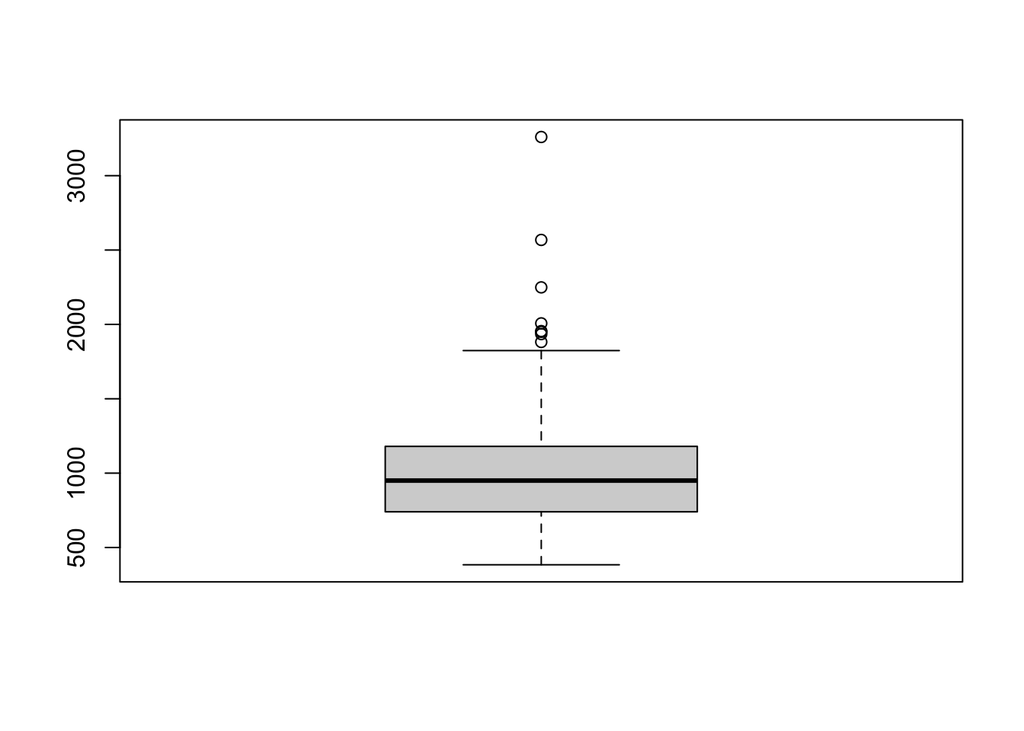

```r
# Interior변수의 boxplot 확인

boxplot(data5$Interior,range = 1.5)
```

```r
# Interior변수에서 1.5 IQR을 넘는 극단값 확인
Lo = quantile(data5$Interior,0.25)-1.5*IQR(data5$Interior)
Up = quantile(data5$Interior,0.75)+1.5*IQR(data5$Interior)
outliers_int =data5$Interior[(data5$Interior<Lo) | (data5$Interior>Up)]
outliers_int
```

```
[1] 1950 1935 2007 1882 2568 1955 2249 3260
```

```r
# Interior변수 극단값의 인덱스 추출 및 제거(data8)
outliers_int_index = which((data5$Interior<Lo) | (data5$Interior>Up))
data6 = data5[-outliers_int_index,]
```

8개 제거

### 3. 너무 크거나 작은 Tax 제거

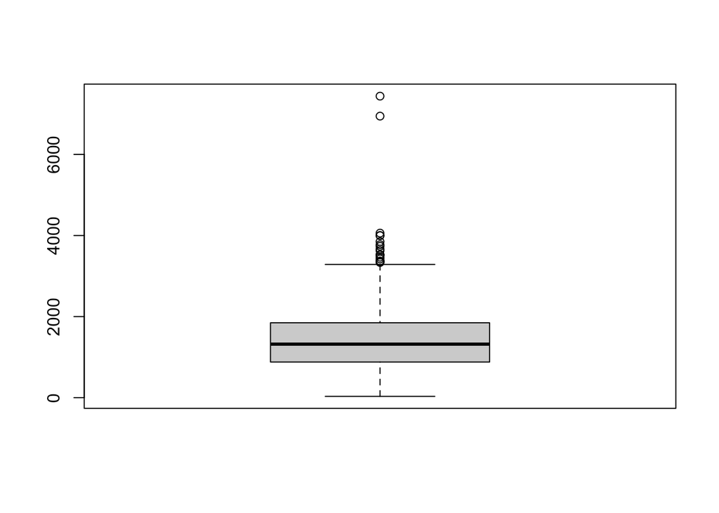

```r
# Tax 변수의 boxplot 확인

boxplot(data6$Tax,range=1.5)
```

```r
# Tax변수에서 3 IQR을 넘는 극단값 확인

Lo = quantile(data6$Tax,0.25)-1.5*IQR(data6$Tax)
Up = quantile(data6$Tax,0.75)+1.5*IQR(data6$Tax)
outliers_tax =data6$Tax[(data6$Tax<Lo) | (data6$Tax>Up)]
outliers_tax
```

```
 [1] 3518 3995 3734 3849 3667 4002 3624 3363 3525 3465 3349 6944 7437 3421 4059
[16] 3774 3335 3522 3368 3368
```

```r
# Tax변수 극단값의 인덱스 추출 및 제거(dataA)

outliers_tax_index = which((data6$Tax<Lo) | (data6$Tax>Up))
data7 = data6[-outliers_tax_index,]
```

20개 제거

### 4. 너무 크거나 작은 Condo 제거

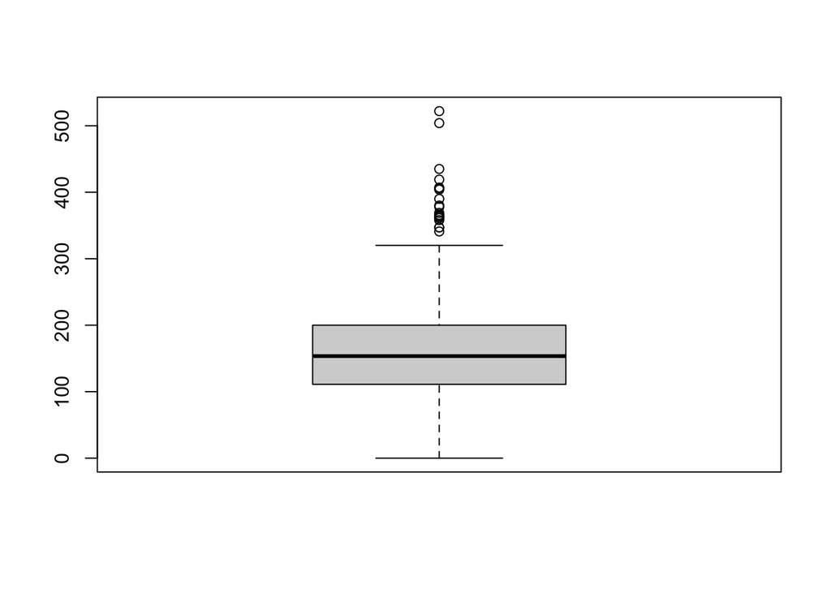

```r
# Condo 변수의 boxplot 확인

boxplot(data7$Condo,range =1.5)
```

```r
# Condo변수에서 1.5 IQR을 넘는 극단값 확인


Lo = quantile(data7$Condo,0.25)-1.5*IQR(data7$Condo)
Up = quantile(data7$Condo,0.75)+1.5*IQR(data7$Condo)
outliers_Condo =data7$Condo[(data7$Condo<Lo) | (data7$Condo>Up)]
outliers_Condo
```

```
 [1] 380 366 390 347 341 378 363 358 364 347 435 419 522 406 504 369 404 361 407
```

```r
# Condo변수 극단값의 인덱스 추출 및 제거(dataB)


outliers_Condo_index = which((data7$Condo<Lo) | (data7$Condo>Up))
data8 = data7[-outliers_Condo_index,]
```

19개 제거

### 5. 너무 많거나 적은 Rooms 제거

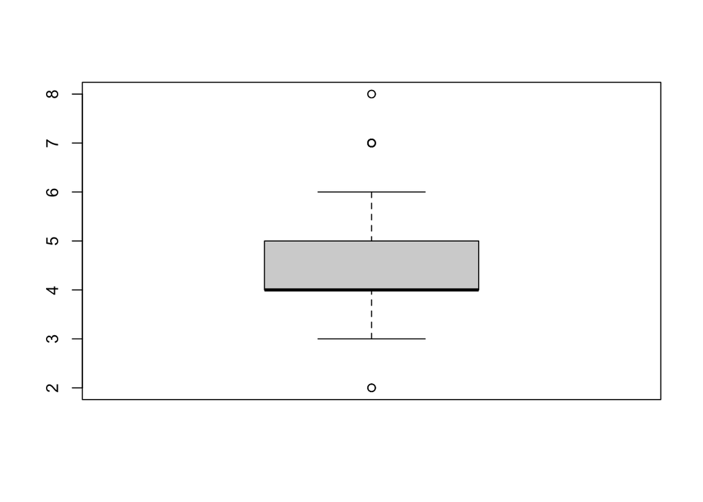

```r
# Rooms 변수의 boxplot 확인

boxplot(data8$Rooms,range = 1.5)
```

```r
# Rooms변수에서 1.5 IQR을 넘는 극단값 확인
Lo = quantile(data8$Rooms,0.25)-1.5*IQR(data8$Rooms)
Up = quantile(data8$Rooms,0.75)+1.5*IQR(data8$Rooms)
outliers_Rooms =data8$Rooms[(data8$Rooms<Lo) | (data8$Rooms>Up)]
outliers_Rooms
```

```
 [1] 8 7 7 7 7 7 8 7 7 7 2 7 7 7 7 7 2 7 2 7
```

```r
# Rooms 변수 극단값의 인덱스 추출 및 제거
outliers_Rooms_index = which((data8$Rooms<Lo) | (data8$Rooms>Up))
data9 = data8[-outliers_Rooms_index,]
```

20개 제거

### 6. 너무 많거나 적은 BED/Rooms = BedPerR 제거

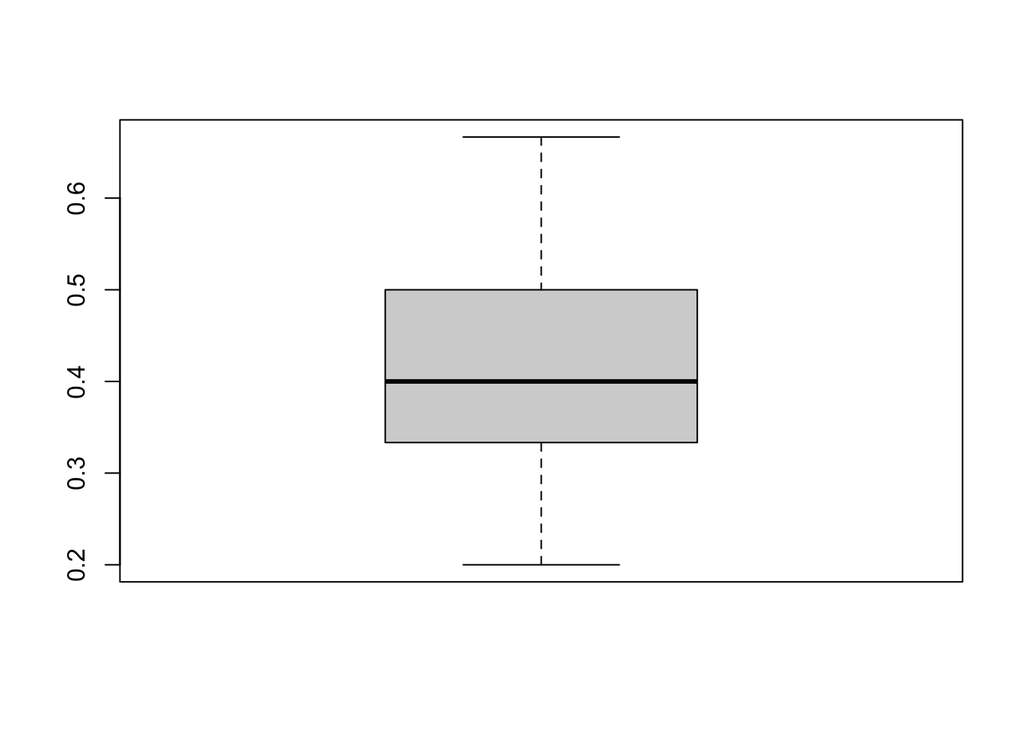

```r
# BedPerR 변수의 boxplot 확인

boxplot(data9$BedPerR, range = 1.5)
```

아웃라이어 보이지 않음 제거 x

### 7. 너무 많거나 적은 BATH/Rooms 제거

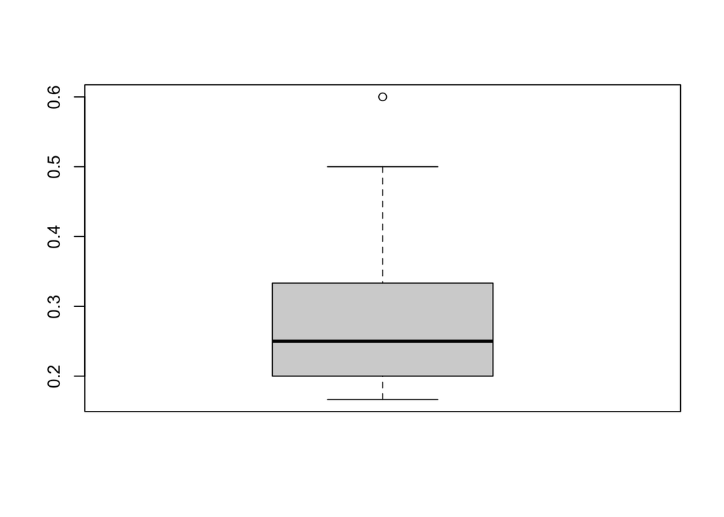

```r
# BathPerR 변수의 boxplot 확인

boxplot(data9$BathPerR,range = 1.5)
```

```r
# BathPerR변수에서 1.5 IQR을 넘는 극단값 확인
Lo = quantile(data9$BathPerR,0.25)-1.5*IQR(data9$BathPerR)
Up = quantile(data9$BathPerR,0.75)+1.5*IQR(data9$BathPerR)
outliers_BathPerR =data9$BathPerR[(data9$BathPerR<Lo) | (data9$BathPerR>Up)]
outliers_BathPerR
```

```
[1] 0.6
```

```r
# BathPerR변수 극단값의 인덱스 추출 및 제거
outliers_BathPerR_index = which((data9$BathPerR<Lo) | (data9$BathPerR>Up))
dataA = data9[-outliers_BathPerR_index,]
```

1개 제거

### 8. Days가 너무 긴 혹은 짧은 데이터 삭제

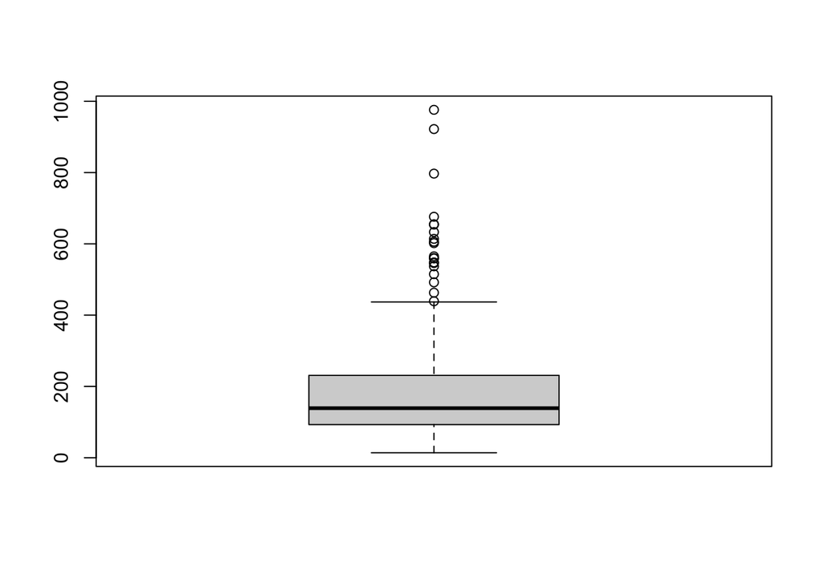

```r
# Days변수의 boxplot 확인
boxplot(dataA$Days, range = 1.5)
```

```r
# Days변수에서 1.5 IQR을 넘는 극단값 확인
Lo = quantile(dataA$Days,0.25)-1.5*IQR(dataA$Days)
Up = quantile(dataA$Days,0.75)+1.5*IQR(dataA$Days)
outliers_days =dataA$Days[(dataA$Days<Lo) | (dataA$Days>Up)]
outliers_days
```

```
 [1] 602 633 515 676 614 655 654 546 437 492 548 559 922 439 976 560 463 797 565
[20] 606 537
```

```r
# Days변수 극단값의 인덱스 추출 및 제거
outliers_days_index = which((dataA$Days<Lo) | (dataA$Days>Up))
dataB = dataA[-outliers_days_index,]
```

21개 제거

### 9. Area 수준별 갯수 확인 10개 미만일경우 제거

```r
# Area factor의 수준별 빈도수 확인
table(dataB$Area)
```

```
AG AH  C CP  E FP HS  K  M  N NW PS RA RS SH  W
10 31  2 20 15  2 69 15 94 13  5 14 33 14  5 23
```

C,FP,NW,SH

```r
# Area변수에서 C,FP,NW,SH만 뽑아내기

outliers_area =dataB$Area[(dataB$Area=="C") | (dataB$Area=="FP")| (dataB$Area=="NW")| (dataB$Area=="SH")]
outliers_area
```

```
 [1] C  FP SH SH SH SH SH FP NW NW NW NW C  NW
Levels: AG AH C CP E FP HS K M N NW PS RA RS SH W
```

```r
# Area변수 C,FP 인덱스 추출 및 제거
outliers_area_index = which((dataB$Area=="C") | (dataB$Area=="FP")| (dataB$Area=="NW")| (dataB$Area=="SH"))

dataC = dataB[-outliers_area_index,]
```

14개 제거

### 10. RC 0,1 갯수 확인 (한쪽이 너무 적으면 제거)

```r
# RC factor의 수준별 빈도수 확인

table(dataC$RC)
```

```
  0   1
113 238
```

둘다 100개 이상의 데이터를 갖고 있으므로 한쪽 제거 안함

### 11. SalePrice ~ Area 분산분석 모형에서 IQR 1.5이상 극단값

```r
# dataC를 이용한 분산분석 모형 M1(SalePrice ~ Area)
dataC = as.tibble(dataC) # 행번호 차례대로 정렬하기 위해 티블로 변경
M1 = aov(SalePrice ~ Area, dataC)
ri = M1$residuals
```

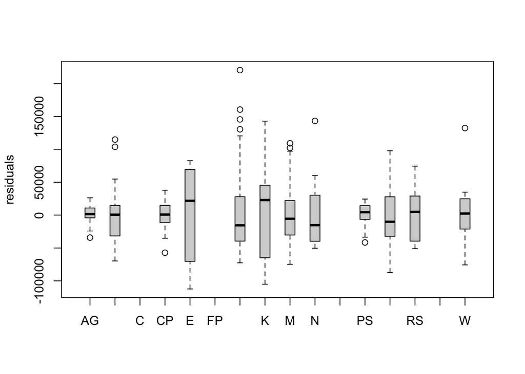

```r
# M1(dataA) outlier 확인(boxplot IQR1.5)
bp =boxplot(ri ~ dataC$Area, xlab = "", ylab = "residuals", range= 1.5, boxwex = 0.4) # boxwex는 상자폭을 0.4배 줄이는 옵션
```

```r
# boxplot에서 극단값 인덱스 반환
outliers = bp$out
outliers
```

```
       10       210       348       118        69       237       317       318
-34150.00 103852.16 114852.16 -57175.00 220513.30 160513.30 130513.30 145513.30
      116       123       176        11       350
102202.13 109202.13 143238.46 -41571.43 132360.87
```

```r
# ri 극단값의 인덱스 추출 및 제거
outliers_index = c(10,210,348,118,69,237,317,318,116,123,176,11,350)
dataD = dataC[-outliers_index,]
```

13개 데이터 제거

### outlier 제거 결과

**Note**

결과적으로 총 338개 관측치의 아래와 같은 데이터만 남았다.

```r
head(dataD)
```

```
# A tibble: 6 × 24
  AddressNo AddressName Street Unit  Area  AreaCode Price1 Price2 SalePrice
  <fct>     <fct>       <fct>  <chr> <fct>    <dbl>  <dbl>  <dbl>     <dbl>
1 73        Allston     St     1     CP           4 109000 109000    106000
2 239       Allston     St     2     CP           4 127000 127000    125000
3 83        Amory       St     3     M            9 123000 100000     95000
4 107       Antrim      St     1     M            9 219000 210000    206000
5 135       Antrim      St     1     M            9 169000 152000    136500
6 95        Antrim      St     3     M            9 245000 214900    202000
# ℹ 15 more variables: YearF <fct>, MonthF <fct>, DateF <fct>,
#   CloseDate <dttm>, Days <dbl>, Interior <dbl>, Bed <dbl>, Bath <dbl>,
#   Rooms <dbl>, Condo <dbl>, Tax <dbl>, RC <fct>, PrPerI <dbl>, BedPerR <dbl>,
#   BathPerR <dbl>
```

## SalePrice ~ Area 분산분석(dataD)

```r
# Area 변수 수준별 빈도수 확인

table(dataD$Area)
```

```
AG AH  C CP  E FP HS  K  M  N NW PS RA RS SH  W
 9 29  0 19 15  0 65 15 92 12  0 13 33 14  0 22
```

```r
# dataB를 이용한 분산분석 M2(SalePrice ~ Area) 정의

M2 = aov(SalePrice ~ Area, dataD)
anova(M2)
```

```
Analysis of Variance Table

Response: SalePrice
           Df     Sum Sq    Mean Sq F value   Pr(>F)
Area       11 5.7672e+10 5242927264  2.7916 0.001736 **
Residuals 326 6.1225e+11 1878077747
---
Signif. codes:  0 '***' 0.001 '**' 0.01 '*' 0.05 '.' 0.1 ' ' 1
```

Area의 모든 평균이 같다는 귀무가설을 기각했다.

등분산성을 확인해보면..

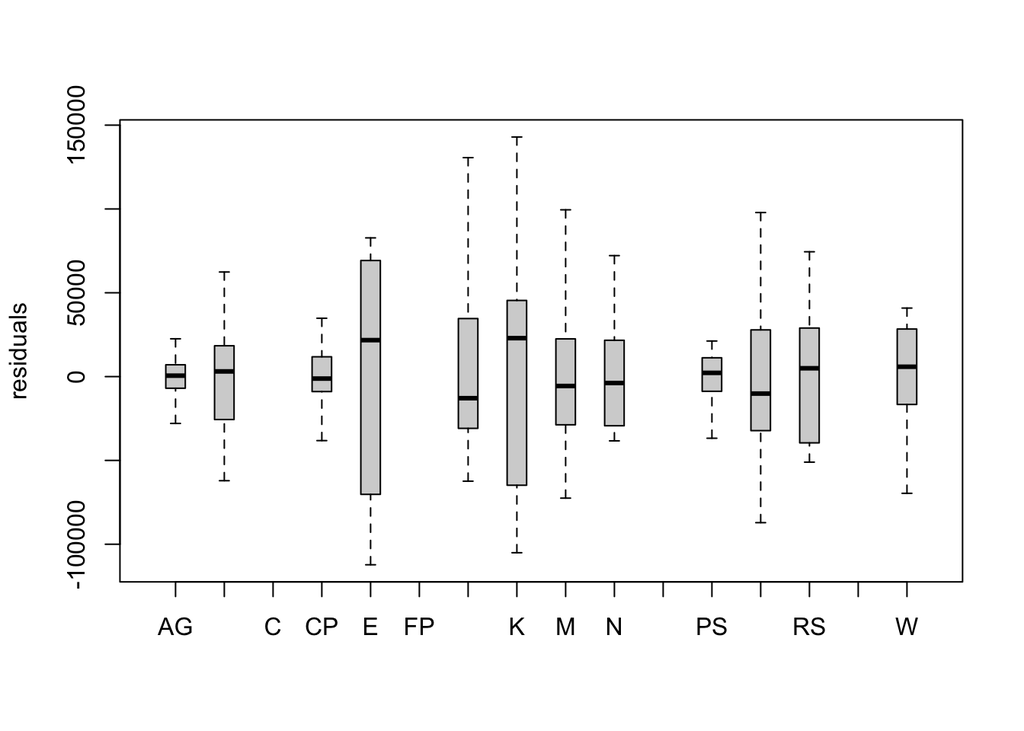

```r
ri = M2$residuals
boxplot(ri ~ dataD$Area, xlab = "", ylab = "residuals", range= 3, boxwex = 0.4) # boxwex는 상자폭을 0.4배 줄이는 옵션
```

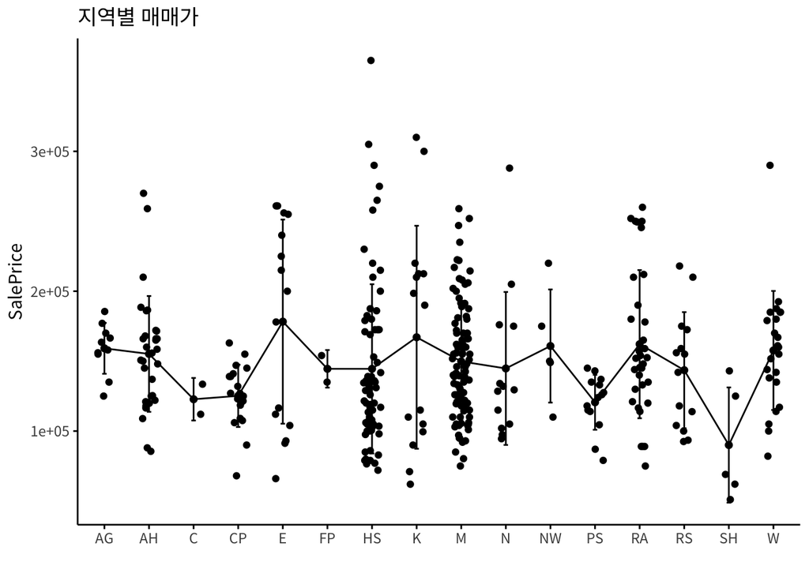

```r
ggpubr::ggline(dataB, x = "Area", y = "SalePrice", add = c("mean_sd", "jitter"),
       title = "지역별 매매가", ylab ="SalePrice", xlab = "", ggtheme = theme_classic(base_family = "Noto Sans KR") )
```

Area별로 분포가 크게 다른 것으로 보아 등분산성을 만족하지 않는 것으로 보인다.

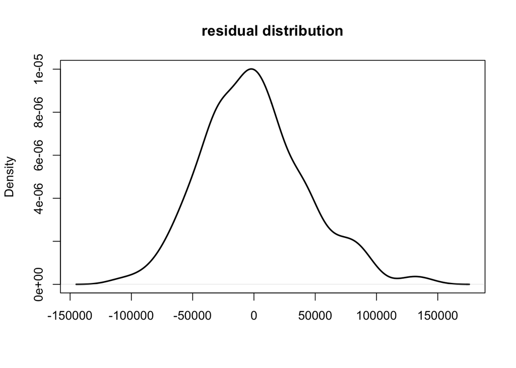

```r
plot(density(M2$residuals),xlab = "",main = "residual distribution", lwd = 2)
```

잔차의 분포가 상당히 정규성을 띄는 분포를 보인다.

그러므로 bartlett test를 이용하여 등분산성을 검정한다.

```r
bartlett.test(SalePrice ~ Area, dataD)
```

```
    Bartlett test of homogeneity of variances

data:  SalePrice by Area
Bartlett's K-squared = 80.965, df = 11, p-value = 9.6e-13
```

p값이(`9.6e-13`) 등분산성을 만족한다는 귀무가설을 기각하고 있기 때문에 등분산성을 갖고 있다고 볼 수 없다.

때문에 비모수검정을 진행한다.

### 비모수검정

```r
kruskal.test(SalePrice ~ Area, dataD)
```

```
    Kruskal-Wallis rank sum test

data:  SalePrice by Area
Kruskal-Wallis chi-squared = 25.193, df = 11, p-value = 0.008542
```

p-value가 매우 작으므로 그룹간 차이가 존재하는 것으로 판단할 수 있다.

사후검정, 다중비교를 진행한다. 작은 차이라도 찾아내기 위해 fisher lsd 검정과 같이 개별 유의수준을 통제하는 방식으로 wilcoxon 검정을 사용한다.

```r
# dataD Wilcoxon 검정 - 다중 비교 사후검정 (순위기반)

pairwise.wilcox.test(dataD$SalePrice, dataD$Area, p.adjust.method = "none")
```

```
    Pairwise comparisons using Wilcoxon rank sum test with continuity correction

data:  dataD$SalePrice and dataD$Area

   AG      AH      CP      E       HS      K       M       N       PS
AH 0.18045 -       -       -       -       -       -       -       -
CP 0.00025 0.01819 -       -       -       -       -       -       -
E  0.47418 0.21108 0.17606 -       -       -       -       -       -
HS 0.01647 0.03398 0.64949 0.06443 -       -       -       -       -
K  0.81144 0.56059 0.49869 0.48063 0.27523 -       -       -       -
M  0.09993 0.71107 0.05075 0.16020 0.01442 0.59960 -       -       -
N  0.02782 0.20220 0.90313 0.17957 0.97199 0.39294 0.17272 -       -
PS 0.00027 0.01094 0.55192 0.19705 0.98395 0.47510 0.03002 0.91336 -
RA 0.34971 0.57246 0.01148 0.47651 0.00642 0.92909 0.25434 0.06273 0.00582
RS 0.17540 0.59511 0.40203 0.20552 0.42969 0.54109 0.68477 0.68067 0.30811
W  0.54206 0.63439 0.01205 0.25871 0.02499 0.51579 0.44654 0.07731 0.00734
   RA      RS
AH -       -
CP -       -
E  -       -
HS -       -
K  -       -
M  -       -
N  -       -
PS -       -
RA -       -
RS 0.38293 -
W  0.88387 0.39862

P value adjustment method: none
```

wilcoxon 검정을 기반으로 두 변수간 p값이 0.1 이하인 경우 붉은 타일이 나타나도록 했다.

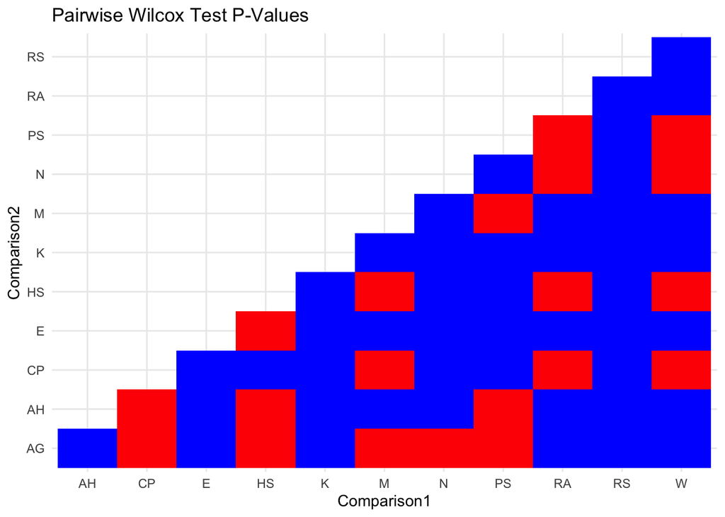

```r
# Area 변수의 순서를 변경한 dataC

dataE = dataD
# Area 변수의 순서를 변경
dataE$Area <- factor(dataD$Area, levels = c("E","K","RA","AG","W" ,"AH","M","RS","HS","N","CP","PS"))
```

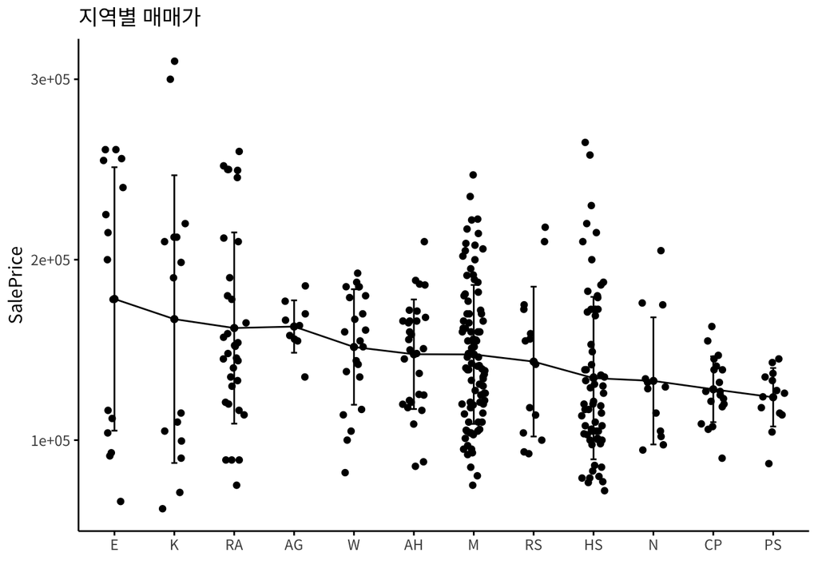

### Area 분산분석 결과

위 분산분석결과를 통해 매매가가 차이 나지 않는 지역을 묶은 새로운 Zone 변수 생성

1Zone = “E”,“K”,“RA”,“AG”  
2Zone = “W”,“AH”, “M”,“RS” 3Zone = “HS”,“N”,“CP”,“PS”

```r
# Zone 변수 추가한 dataF

dataF = dataE
for(i in 1:nrow(dataF)){
  if(dataF$Area[i] == "E"|dataF$Area[i] == "K"|dataF$Area[i] == "RA"|dataF$Area[i] == "AG"){
    dataF$Zone[i] = "1Zone"
    }
  else if(dataF$Area[i] == "W"|dataF$Area[i] == "AH"|dataF$Area[i] == "M"|dataF$Area[i] == "RS"){
    dataF$Zone[i] = "2Zone"
    }
  else if(dataF$Area[i] == "HS"|dataF$Area[i] == "N"|dataF$Area[i] == "CP"|dataF$Area[i] == "PS"){
    dataF$Zone[i] = "3Zone"
    }
}
dataF$Zone = as.factor(dataF$Zone)
```

```r
head(dataF)
```

```
# A tibble: 6 × 25
  AddressNo AddressName Street Unit  Area  AreaCode Price1 Price2 SalePrice
  <fct>     <fct>       <fct>  <chr> <fct>    <dbl>  <dbl>  <dbl>     <dbl>
1 73        Allston     St     1     CP           4 109000 109000    106000
2 239       Allston     St     2     CP           4 127000 127000    125000
3 83        Amory       St     3     M            9 123000 100000     95000
4 107       Antrim      St     1     M            9 219000 210000    206000
5 135       Antrim      St     1     M            9 169000 152000    136500
6 95        Antrim      St     3     M            9 245000 214900    202000
# ℹ 16 more variables: YearF <fct>, MonthF <fct>, DateF <fct>,
#   CloseDate <dttm>, Days <dbl>, Interior <dbl>, Bed <dbl>, Bath <dbl>,
#   Rooms <dbl>, Condo <dbl>, Tax <dbl>, RC <fct>, PrPerI <dbl>, BedPerR <dbl>,
#   BathPerR <dbl>, Zone <fct>
```

## SalePrice ~ YearF 분산분석(dataF)

```r
# dataD를 이용한 SalePrice ~ YearF분산분석 M3 정의


M3 = aov(SalePrice ~ YearF, dataF)
anova(M3)
```

```
Analysis of Variance Table

Response: SalePrice
           Df     Sum Sq    Mean Sq F value   Pr(>F)
YearF       5 3.8489e+10 7697718843  4.0473 0.001403 **
Residuals 332 6.3144e+11 1901918528
---
Signif. codes:  0 '***' 0.001 '**' 0.01 '*' 0.05 '.' 0.1 ' ' 1
```

## HousePriceIndex사용

All-Transactions House Price Index for Cambridge-Newton-Framingham, MA (MSAD)https://fred.stlouisfed.org/series/ATNHPIUS15764Q

quarter 기간별 자료이므로 quarter 열을 만들어준다.

```r
dataG = dataF
```

```r
# dataG의 연도 수준 확인

table(dataG$YearF)
```

```
1920 1988 1989 1990 1991 1992 1993 1994
   0    0   17   60   68   75  115    3
```

```r
# dataG에 quarter지정

for(i in 1:nrow(dataG)){
    if(dataG$YearF[i] == "1989"){
      if(dataG$MonthF[i] == "01"|dataG$MonthF[i] == "02"|dataG$MonthF[i] == "03"){
        dataG$Quarter[i] = "1989-1Q"
      }
      else if(dataG$MonthF[i] == "04"|dataG$MonthF[i] == "05"|dataG$MonthF[i] == "06"){
        dataG$Quarter[i] = "1989-2Q"
      }
      else if(dataG$MonthF[i] == "07"|dataG$MonthF[i] == "08"|dataG$MonthF[i] == "09"){
        dataG$Quarter[i] = "1989-3Q"
      }
      else if(dataG$MonthF[i] == "10"|dataG$MonthF[i] == "11"|dataG$MonthF[i] == "12"){
        dataG$Quarter[i] = "1989-4Q"
      }
    }
  else if(dataG$YearF[i] == "1990"){
    if(dataG$MonthF[i] == "01"|dataG$MonthF[i] == "02"|dataG$MonthF[i] == "03"){
        dataG$Quarter[i] = "1990-1Q"
      }
      else if(dataG$MonthF[i] == "04"|dataG$MonthF[i] == "05"|dataG$MonthF[i] == "06"){
        dataG$Quarter[i] = "1990-2Q"
      }
      else if(dataG$MonthF[i] == "07"|dataG$MonthF[i] == "08"|dataG$MonthF[i] == "09"){
        dataG$Quarter[i] = "1990-3Q"
      }
      else if(dataG$MonthF[i] == "10"|dataG$MonthF[i] == "11"|dataG$MonthF[i] == "12"){
        dataG$Quarter[i] = "1990-4Q"
      }
  }
  else if(dataG$YearF[i] == "1991"){
    if(dataG$MonthF[i] == "01"|dataG$MonthF[i] == "02"|dataG$MonthF[i] == "03"){
        dataG$Quarter[i] = "1991-1Q"
      }
      else if(dataG$MonthF[i] == "04"|dataG$MonthF[i] == "05"|dataG$MonthF[i] == "06"){
        dataG$Quarter[i] = "1991-2Q"
      }
      else if(dataG$MonthF[i] == "07"|dataG$MonthF[i] == "08"|dataG$MonthF[i] == "09"){
        dataG$Quarter[i] = "1991-3Q"
      }
      else if(dataG$MonthF[i] == "10"|dataG$MonthF[i] == "11"|dataG$MonthF[i] == "12"){
        dataG$Quarter[i] = "1991-4Q"
      }
  }
  else if(dataG$YearF[i] == "1992"){
    if(dataG$MonthF[i] == "01"|dataG$MonthF[i] == "02"|dataG$MonthF[i] == "03"){
        dataG$Quarter[i] = "1992-1Q"
      }
      else if(dataG$MonthF[i] == "04"|dataG$MonthF[i] == "05"|dataG$MonthF[i] == "06"){
        dataG$Quarter[i] = "1992-2Q"
      }
      else if(dataG$MonthF[i] == "07"|dataG$MonthF[i] == "08"|dataG$MonthF[i] == "09"){
        dataG$Quarter[i] = "1992-3Q"
      }
      else if(dataG$MonthF[i] == "10"|dataG$MonthF[i] == "11"|dataG$MonthF[i] == "12"){
        dataG$Quarter[i] = "1992-4Q"
      }
  }
  else if(dataG$YearF[i] == "1993"){
    if(dataG$MonthF[i] == "01"|dataG$MonthF[i] == "02"|dataG$MonthF[i] == "03"){
        dataG$Quarter[i] = "1993-1Q"
      }
      else if(dataG$MonthF[i] == "04"|dataG$MonthF[i] == "05"|dataG$MonthF[i] == "06"){
        dataG$Quarter[i] = "1993-2Q"
      }
      else if(dataG$MonthF[i] == "07"|dataG$MonthF[i] == "08"|dataG$MonthF[i] == "09"){
        dataG$Quarter[i] = "1993-3Q"
      }
      else if(dataG$MonthF[i] == "10"|dataG$MonthF[i] == "11"|dataG$MonthF[i] == "12"){
        dataG$Quarter[i] = "1993-4Q"
      }
  }
  else if(dataG$YearF[i] == "1994"){
    if(dataG$MonthF[i] == "01"|dataG$MonthF[i] == "02"|dataG$MonthF[i] == "03"){
        dataG$Quarter[i] = "1994-1Q"
      }
      else if(dataG$MonthF[i] == "04"|dataG$MonthF[i] == "05"|dataG$MonthF[i] == "06"){
        dataG$Quarter[i] = "1994-2Q"
      }
      else if(dataG$MonthF[i] == "07"|dataG$MonthF[i] == "08"|dataG$MonthF[i] == "09"){
        dataG$Quarter[i] = "1994-3Q"
      }
      else if(dataG$MonthF[i] == "10"|dataG$MonthF[i] == "11"|dataG$MonthF[i] == "12"){
        dataG$Quarter[i] = "1994-4Q"
      }
  }
}
dataG$Quarter = as.factor(dataG$Quarter)
```

### HousePrieIndex열 만들기

```r
# dataE에 quarter별 HousePriceIndex 지정

for(i in 1:nrow(dataG)){
    if(dataG$Quarter[i] == "1989-1Q"){
     dataG$HousePriceIndex[i] = 107.8
    }
  else if(dataG$Quarter[i] == "1989-2Q"){
     dataG$HousePriceIndex[i] = 106.99
  }
  else if(dataG$Quarter[i] == "1989-3Q"){
     dataG$HousePriceIndex[i] = 108.63
  }
  else if(dataG$Quarter[i] == "1989-4Q"){
     dataG$HousePriceIndex[i] = 108.92
  }
  else if(dataG$Quarter[i] == "1990-1Q"){
     dataG$HousePriceIndex[i] = 107.5
  }
  else if(dataG$Quarter[i] == "1990-2Q"){
     dataG$HousePriceIndex[i] = 104.33
  }
  else if(dataG$Quarter[i] == "1990-3Q"){
     dataG$HousePriceIndex[i] = 101.98
  }
  else if(dataG$Quarter[i] == "1990-4Q"){
     dataG$HousePriceIndex[i] = 100.21
  }
  else if(dataG$Quarter[i] == "1991-1Q"){
     dataG$HousePriceIndex[i] = 98.75
  }
  else if(dataG$Quarter[i] == "1991-2Q"){
     dataG$HousePriceIndex[i] = 97.70
  }
  else if(dataG$Quarter[i] == "1991-3Q"){
     dataG$HousePriceIndex[i] = 96.87
  }
  else if(dataG$Quarter[i] == "1991-4Q"){
     dataG$HousePriceIndex[i] = 97.68
  }
  else if(dataG$Quarter[i] == "1992-1Q"){
     dataG$HousePriceIndex[i] = 97.62
  }
  else if(dataG$Quarter[i] == "1992-2Q"){
     dataG$HousePriceIndex[i] = 96.83
  }
  else if(dataG$Quarter[i] == "1992-3Q"){
     dataG$HousePriceIndex[i] = 97.6
  }
  else if(dataG$Quarter[i] == "1992-4Q"){
     dataG$HousePriceIndex[i] = 97.82
  }
  else if(dataG$Quarter[i] == "1993-1Q"){
     dataG$HousePriceIndex[i] = 97.56
  }
  else if(dataG$Quarter[i] == "1993-2Q"){
     dataG$HousePriceIndex[i] = 98.06
  }
  else if(dataG$Quarter[i] == "1993-3Q"){
     dataG$HousePriceIndex[i] = 98.70
  }
  else if(dataG$Quarter[i] == "1993-4Q"){
     dataG$HousePriceIndex[i] = 99.45
  }
  else if(dataG$Quarter[i] == "1994-1Q"){
     dataG$HousePriceIndex[i] = 99.74
  }
  else if(dataG$Quarter[i] == "1994-2Q"){
     dataG$HousePriceIndex[i] = 99.38
  }
  else if(dataG$Quarter[i] == "1994-3Q"){
     dataG$HousePriceIndex[i] = 99.78
  }
  else if(dataG$Quarter[i] == "1994-4Q"){
     dataG$HousePriceIndex[i] = 98.79
  }
  else{
    dataG$HousePriceIndex[i] = 0
  }
}
```

## 다중회귀분석

```r
# dataG 구조 확인
str(dataG)
```

```
tibble [338 × 27] (S3: tbl_df/tbl/data.frame)
 $ AddressNo      : Factor w/ 146 levels "1","10","10]",..: 128 57 133 6 19 139 97 19 18 45 ...
 $ AddressName    : Factor w/ 112 levels "Allston","Amory",..: 1 1 2 3 3 3 3 3 3 7 ...
 $ Street         : Factor w/ 16 levels "Auburn","Ave",..: 14 14 14 14 14 14 14 14 14 3 ...
 $ Unit           : chr [1:338] "1" "2" "3" "1" ...
 $ Area           : Factor w/ 12 levels "E","K","RA","AG",..: 11 11 7 7 7 7 7 7 7 7 ...
 $ AreaCode       : num [1:338] 4 4 9 9 9 9 9 9 9 9 ...
 $ Price1         : num [1:338] 109000 127000 123000 219000 169000 ...
 $ Price2         : num [1:338] 109000 127000 100000 210000 152000 ...
 $ SalePrice      : num [1:338] 106000 125000 95000 206000 136500 ...
 $ YearF          : Factor w/ 8 levels "1920","1988",..: 7 7 7 5 6 6 7 7 7 6 ...
 $ MonthF         : Factor w/ 12 levels "01","02","03",..: 7 8 3 3 5 8 5 6 9 9 ...
 $ DateF          : Factor w/ 31 levels "01","02","03",..: 17 21 6 17 30 8 18 19 24 26 ...
 $ CloseDate      : POSIXct[1:338], format: "1993-10-22" "1993-10-22" ...
 $ Days           : num [1:338] 97 62 208 159 116 160 80 157 123 328 ...
 $ Interior       : num [1:338] 834 850 730 1460 1225 ...
 $ Bed            : num [1:338] 2 2 2 3 2 2 3 3 3 1 ...
 $ Bath           : num [1:338] 1 1 1 2 1 1 1 1 1 1 ...
 $ Rooms          : num [1:338] 4 5 4 6 6 6 5 6 6 4 ...
 $ Condo          : num [1:338] 70 100 185 100 100 100 163 150 100 115 ...
 $ Tax            : num [1:338] 490 923 575 1582 1698 ...
 $ RC             : Factor w/ 2 levels "0","1": 1 2 1 2 2 2 1 2 2 2 ...
 $ PrPerI         : num [1:338] 127 147 130 141 111 ...
 $ BedPerR        : num [1:338] 0.5 0.4 0.5 0.5 0.333 ...
 $ BathPerR       : num [1:338] 0.25 0.2 0.25 0.333 0.167 ...
 $ Zone           : Factor w/ 3 levels "1Zone","2Zone",..: 3 3 2 2 2 2 2 2 2 2 ...
 $ Quarter        : Factor w/ 20 levels "1989-2Q","1989-3Q",..: 18 18 16 8 13 14 17 17 18 14 ...
 $ HousePriceIndex: num [1:338] 98.7 98.7 97.6 98.8 96.8 ...
```

### 다중 회귀 모형 Fullmodel(skip)

```
# LM1 = 모든 변수 상호작용 고려한 다중 회귀 모형
LM1 = lm(PrPerI ~ Interior * Zone * YearM * Days * Rooms * Bed * Bath * Condo * Tax * RC, dataG)
```

```
# LM1의 MSE 확인

F1 = anova(LM1)
F1[218,3] # LM1의 MSE

아래는 Fullmodel의 MSE
[1] 267.9195
```

```
# LM1을 활용한 Reyeme Affiar의 건물 가격 예측

predict(LM1, newdata = data.frame(Interior = 1040, Zone = "5Zone",YearM = "1994", Days = 24, Rooms = 5, Bed = 2, Bath = 1, Condo = 175 , Tax = 1121 , RC = "1"), interval = "prediction") #Days 24일은 4월 11일 ~ 5월 4일(당일 구매시) 기간 계산
#5Zone 은 건물이 위치한 Mid Cambridge(Area:M)의 Zone
```

**결과**

다중공선성 때문인지 완전히 이상한 값이 나옴.

### 다중 회귀 모형 - 단계별 선택법

```r
# 상호작용을 고려하지 않은 LM2 다중회귀 모형

LM2 = lm(SalePrice ~ Interior + Zone + HousePriceIndex + Days + Rooms + Bed + Bath + Condo + Tax + RC, dataG)
```

```r
# LM2 다중회귀 모형의 MSE확인

F2 = anova(LM2)
F2[11,3] # LM2의 MSE : 715,208,196
```

```
[1] 715208196
```

```r
# LM2 다중회귀 모형의 model selection 단계별 선택법

step = stepAIC(LM2, scope = list(upper = ~ Interior*Zone*HousePriceIndex*Days * Rooms * Bed * Bath * Condo * Tax * RC, lower = ~1),direction="both",trace = FALSE )
```

```r
# LM2 다중회귀 모형의 model selection 단계별 선택법 결과

step$anova
```

```
Stepwise Model Path
Analysis of Deviance Table

Initial Model:
SalePrice ~ Interior + Zone + HousePriceIndex + Days + Rooms +
    Bed + Bath + Condo + Tax + RC

Final Model:
SalePrice ~ Interior + Zone + HousePriceIndex + Days + Rooms +
    Bed + Bath + Condo + Tax + RC + Zone:Tax + Rooms:Bath + Interior:Zone +
    Zone:Bath + Condo:RC + Days:Bath + Bed:RC + Interior:Rooms +
    Interior:Tax + Rooms:Bed + Interior:Zone:Tax

                  Step Df    Deviance Resid. Df   Resid. Dev      AIC
1                                           326 233157871982 6902.954
2           + Zone:Tax  2 12260170046       324 220897701935 6888.697
3         + Rooms:Bath  1  8782577705       323 212115124230 6876.984
4      + Interior:Zone  2  6206866278       321 205908257953 6870.946
5          + Zone:Bath  2  5495005933       319 200413252020 6865.803
6           + Condo:RC  1  5484529011       318 194928723008 6858.425
7          + Days:Bath  1  3129978980       317 191798744028 6854.953
8             + Bed:RC  1  2218764051       316 189579979978 6853.020
9     + Interior:Condo  1  2498672563       315 187081307415 6850.536
10    + Interior:Rooms  1  1754376756       314 185326930659 6849.351
11      + Interior:Tax  1  2319471015       313 183007459644 6847.094
12 + Interior:Zone:Tax  2  3517615143       311 179489844501 6844.534
13         + Rooms:Bed  1  1987406171       310 177502438330 6842.771
14    - Interior:Condo  1   218408414       311 177720846743 6841.187
```

```r
# 단계별 선택법에 의해 도출된 LM3

LM3 =lm(SalePrice ~ Interior + Zone + HousePriceIndex + Days + Rooms +
    Bed + Bath + Condo + Tax + RC + Zone:Tax + Rooms:Bath + Interior:Zone +
    Zone:Bath + Condo:RC + Days:Bath + Bed:RC + Interior:Rooms +
    Interior:Tax + Rooms:Bed + Interior:Zone:Tax,dataG)
F3 = anova(LM3)
F3[22,3] # MSE = 571,449,668
```

```
[1] 571449668
```

### LM3을 통한 Reyeme Affiar의 건물 가격 예측

```r
# LM3을 활용한 Reyeme Affiar의 건물 가격 예측

pre = predict(LM3, newdata = data.frame(Interior = 1040, Zone = "2Zone",HousePriceIndex = 99.38, Days = 24, Rooms = 5, Bed = 2, Bath = 1, Condo = 175 , Tax = 1121 , RC = "1"), interval = "prediction")
#Days 24일은 4월 11일 ~ 5월 4일(당일 구매시) 기간 계산
#5Zone 은 건물이 위치한 Mid Cambridge(Area:M)의 Zone
pre
```

```
       fit      lwr      upr
1 166286.1 118604.5 213967.7
```

```r
# 신뢰구간 크기
213967.7 - 118604.5
```

```
[1] 95363.2
```

## 다중공선성 및 영향점 확인

### LM3모형에 사용한 변수간 상관관계 확인(수치형 변수만)

```r
dataG_N = dataG[,c("SalePrice","Interior","Days","Rooms","Bed","Bath","Condo","Tax","HousePriceIndex")]
```

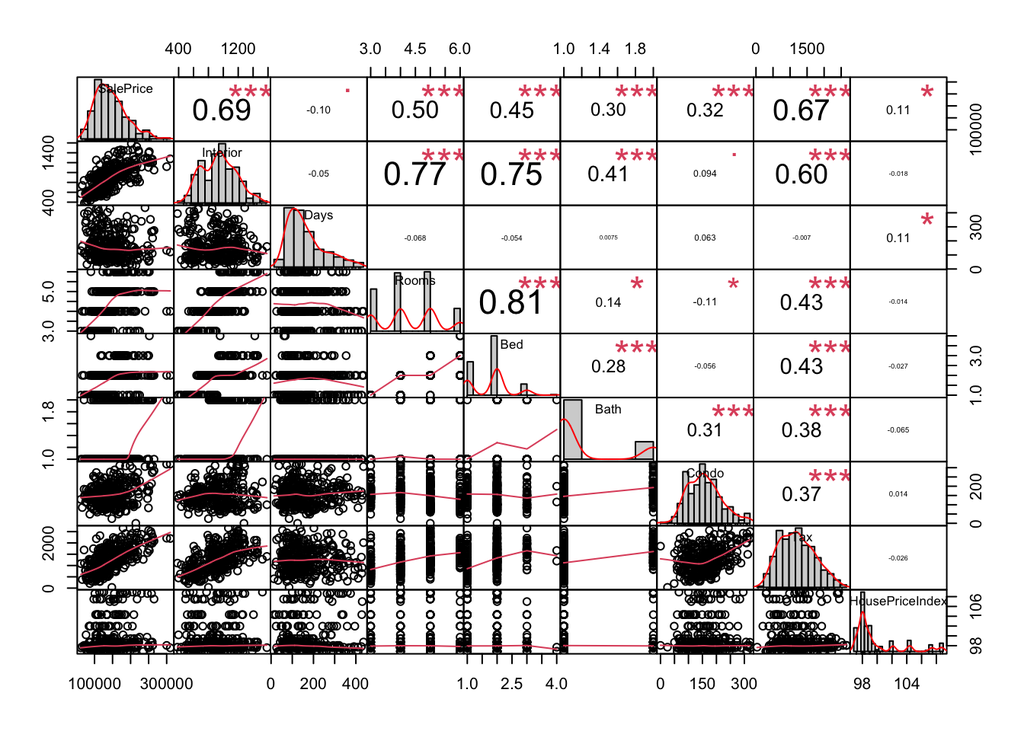

```r
chart.Correlation(dataG_N)
```

Interior - Rooms  
Interior - Bed Interior - Bath  
Interior - Tax Rooms - Bed

위 변수간에 상관관계가 특히 높다.

LM3 다중회귀모형의 회귀계수를 살펴보자.

```r
LM3$coefficients
```

```
           (Intercept)               Interior              Zone2Zone
         -3.072488e+04           1.750194e+02          -8.728067e+04
             Zone3Zone        HousePriceIndex                   Days
         -4.096614e+04           1.919933e+03          -1.366535e+02
                 Rooms                    Bed                   Bath
          1.021616e+03          -4.828519e+04          -1.413967e+05
                 Condo                    Tax                    RC1
          1.357073e+02          -4.901109e+01          -7.290043e+03
         Zone2Zone:Tax          Zone3Zone:Tax             Rooms:Bath
          4.774142e+01           5.767640e+01           2.193911e+04
    Interior:Zone2Zone     Interior:Zone3Zone         Zone2Zone:Bath
          7.745462e+01          -4.145244e+00           3.681951e+04
        Zone3Zone:Bath              Condo:RC1              Days:Bath
          2.826178e+04          -1.017088e+02           8.035388e+01
               Bed:RC1         Interior:Rooms           Interior:Tax
          1.463686e+04          -3.596664e+01           9.150270e-02
             Rooms:Bed Interior:Zone2Zone:Tax Interior:Zone3Zone:Tax
          6.369594e+03          -7.826653e-02          -6.138838e-02
```

```r
F3
```

```
Analysis of Variance Table

Response: SalePrice
                   Df     Sum Sq    Mean Sq  F value    Pr(>F)
Interior            1 3.1925e+11 3.1925e+11 558.6599 < 2.2e-16 ***
Zone                2 3.6661e+10 1.8331e+10  32.0772 2.161e-13 ***
HousePriceIndex     1 1.2689e+10 1.2689e+10  22.2055 3.700e-06 ***
Days                1 3.0559e+09 3.0559e+09   5.3476 0.0214032 *
Rooms               1 1.4262e+09 1.4262e+09   2.4957 0.1151736
Bed                 1 3.6884e+09 3.6884e+09   6.4545 0.0115529 *
Bath                1 1.0087e+08 1.0087e+08   0.1765 0.6746723
Condo               1 2.6501e+10 2.6501e+10  46.3758 5.047e-11 ***
Tax                 1 3.2299e+10 3.2299e+10  56.5215 5.987e-13 ***
RC                  1 1.0993e+09 1.0993e+09   1.9236 0.1664504
Zone:Tax            2 1.2260e+10 6.1301e+09  10.7273 3.125e-05 ***
Rooms:Bath          1 8.7826e+09 8.7826e+09  15.3689 0.0001088 ***
Interior:Zone       2 6.2069e+09 3.1034e+09   5.4308 0.0048049 **
Zone:Bath           2 5.4950e+09 2.7475e+09   4.8080 0.0087814 **
Condo:RC            1 5.4845e+09 5.4845e+09   9.5976 0.0021262 **
Days:Bath           1 3.1300e+09 3.1300e+09   5.4773 0.0198973 *
Bed:RC              1 2.2188e+09 2.2188e+09   3.8827 0.0496730 *
Interior:Rooms      1 1.8029e+09 1.8029e+09   3.1549 0.0766778 .
Interior:Tax        1 4.1776e+09 4.1776e+09   7.3105 0.0072324 **
Rooms:Bed           1 1.5815e+09 1.5815e+09   2.7676 0.0971977 .
Interior:Zone:Tax   2 4.2972e+09 2.1486e+09   3.7599 0.0243522 *
Residuals         311 1.7772e+11 5.7145e+08
---
Signif. codes:  0 '***' 0.001 '**' 0.01 '*' 0.05 '.' 0.1 ' ' 1
```

**Note**

Bed와 Bath의 회귀계수에 문제가 있어보이나, Bed 혹은 Bath와 Bed 혹은 Bath가 속한 상호작용을 제거할 경우, MSE가 지속해서 증가하여 예측력이 떨어지는 것을 확인하였다. 때문에 다중공선성 문제보단 영향점을 제거하는데에 집중했다.

### 잔차 분석

```r
gvlma(LM3)
```

```
Call:
lm(formula = SalePrice ~ Interior + Zone + HousePriceIndex +
    Days + Rooms + Bed + Bath + Condo + Tax + RC + Zone:Tax +
    Rooms:Bath + Interior:Zone + Zone:Bath + Condo:RC + Days:Bath +
    Bed:RC + Interior:Rooms + Interior:Tax + Rooms:Bed + Interior:Zone:Tax,
    data = dataG)

Coefficients:
           (Intercept)                Interior               Zone2Zone
            -3.072e+04               1.750e+02              -8.728e+04
             Zone3Zone         HousePriceIndex                    Days
            -4.097e+04               1.920e+03              -1.367e+02
                 Rooms                     Bed                    Bath
             1.022e+03              -4.829e+04              -1.414e+05
                 Condo                     Tax                     RC1
             1.357e+02              -4.901e+01              -7.290e+03
         Zone2Zone:Tax           Zone3Zone:Tax              Rooms:Bath
             4.774e+01               5.768e+01               2.194e+04
    Interior:Zone2Zone      Interior:Zone3Zone          Zone2Zone:Bath
             7.745e+01              -4.145e+00               3.682e+04
        Zone3Zone:Bath               Condo:RC1               Days:Bath
             2.826e+04              -1.017e+02               8.035e+01
               Bed:RC1          Interior:Rooms            Interior:Tax
             1.464e+04              -3.597e+01               9.150e-02
             Rooms:Bed  Interior:Zone2Zone:Tax  Interior:Zone3Zone:Tax
             6.370e+03              -7.827e-02              -6.139e-02


ASSESSMENT OF THE LINEAR MODEL ASSUMPTIONS
USING THE GLOBAL TEST ON 4 DEGREES-OF-FREEDOM:
Level of Significance =  0.05

Call:
 gvlma(x = LM3)

                      Value p-value                   Decision
Global Stat        367.8211 0.00000 Assumptions NOT satisfied!
Skewness             7.5930 0.00586 Assumptions NOT satisfied!
Kurtosis           356.2798 0.00000 Assumptions NOT satisfied!
Link Function        0.2561 0.61283    Assumptions acceptable.
Heteroscedasticity   3.6923 0.05466    Assumptions acceptable.
```

gvlma 결과 영향점 있을 수 있다고 판단한다.

### 영향점 확인

```r
outliers_inf = abs(rstudent(LM3))>1.5
cbind(dataE[outliers_inf,],rstud = rstudent(LM3)[outliers_inf])
```

```
    AddressNo AddressName Street Unit Area AreaCode Price1 Price2 SalePrice
7          43      Antrim     St    3    M        9 194000 194000    189000
19         10        Avon     St    2   AH        2 197500 169500    166000
27         41     Bowdoin     St   43   RA       13 203800 169900    152000
28        246     Brattle     St   41    W       16 179000 165000    144000
71         20    Chestnut     St  403   CP        4 145000 138000    132000
79          5     Chilton     St    3    M        9 249000 249000    235000
100     River       Court   <NA>  606    K        8 339000 339000    310000
101     River       Court   <NA>  216    K        8 225000 225000    212500
102     River       Court   <NA>  701    K        8 315000 315000    300000
123       170        Gore     St  314    E        5  99000  99000     91250
154       280     Harvard     St   LD    M        9 145000 105000     97000
158       352     Harvard     St   1D   HS        7 229000 229000    220000
174        12       Inman     St   51    M        9 149000 119000    106000
175        12       Inman     St   21    M        9 139900 113000    105000
```

[output cut: 72 more lines]

```r
outliers_inf_index = which(outliers_inf)
```

```r
dataH = dataG[-outliers_inf_index,]
```

```r
# 영향점 제거 후 LM3

LM3 =lm(SalePrice ~ Interior + Zone + HousePriceIndex + Days + Rooms +
    Bed + Bath + Condo + Tax + RC + Zone:Tax + Rooms:Bath + Interior:Zone +
    Zone:Bath + Condo:RC + Days:Bath + Bed:RC + Interior:Rooms +
    Interior:Tax + Rooms:Bed + Interior:Zone:Tax,dataH)
F3 = anova(LM3)
F3[22,3] # MSE = 259,626,691 (이전보다 반으로 줄어듦 571,449,668)
```

```
[1] 259626691
```

```r
F3
```

```
Analysis of Variance Table

Response: SalePrice
                   Df     Sum Sq    Mean Sq   F value    Pr(>F)
Interior            1 2.8640e+11 2.8640e+11 1103.1051 < 2.2e-16 ***
Zone                2 4.1369e+10 2.0684e+10   79.6694 < 2.2e-16 ***
HousePriceIndex     1 1.1726e+10 1.1726e+10   45.1667 9.946e-11 ***
Days                1 4.3986e+09 4.3986e+09   16.9421 5.060e-05 ***
Rooms               1 1.8155e+09 1.8155e+09    6.9926 0.0086415 **
Bed                 1 3.9586e+09 3.9586e+09   15.2474 0.0001180 ***
Bath                1 1.3430e+07 1.3430e+07    0.0517 0.8202441
Condo               1 1.9153e+10 1.9153e+10   73.7718 5.981e-16 ***
Tax                 1 3.6231e+10 3.6231e+10  139.5489 < 2.2e-16 ***
RC                  1 9.7797e+08 9.7797e+08    3.7668 0.0532716 .
Zone:Tax            2 1.7380e+10 8.6900e+09   33.4713 8.958e-14 ***
Rooms:Bath          1 9.1333e+09 9.1333e+09   35.1787 8.754e-09 ***
Interior:Zone       2 6.7598e+09 3.3799e+09   13.0183 3.903e-06 ***
Zone:Bath           2 3.7627e+09 1.8814e+09    7.2465 0.0008528 ***
Condo:RC            1 3.8838e+09 3.8838e+09   14.9593 0.0001364 ***
Days:Bath           1 4.0836e+09 4.0836e+09   15.7289 9.267e-05 ***
Bed:RC              1 4.3710e+09 4.3710e+09   16.8357 5.335e-05 ***
Interior:Rooms      1 1.9870e+09 1.9870e+09    7.6534 0.0060395 **
Interior:Tax        1 4.9622e+09 4.9622e+09   19.1127 1.733e-05 ***
Rooms:Bed           1 4.2460e+08 4.2460e+08    1.6354 0.2020025
Interior:Zone:Tax   2 7.0722e+09 3.5361e+09   13.6200 2.252e-06 ***
Residuals         283 7.3474e+10 2.5963e+08
---
Signif. codes:  0 '***' 0.001 '**' 0.01 '*' 0.05 '.' 0.1 ' ' 1
```

```r
LM3$coefficients
```

```
           (Intercept)               Interior              Zone2Zone
          2.564242e+04           1.239674e+02          -1.146844e+05
             Zone3Zone        HousePriceIndex                   Days
         -6.077211e+04           1.915463e+03          -1.614481e+02
                 Rooms                    Bed                   Bath
         -1.716450e+02          -4.464418e+04          -1.625397e+05
                 Condo                    Tax                    RC1
          9.947498e+01          -6.459070e+01          -2.386022e+04
         Zone2Zone:Tax          Zone3Zone:Tax             Rooms:Bath
          6.330498e+01           7.477819e+01           2.631630e+04
    Interior:Zone2Zone     Interior:Zone3Zone         Zone2Zone:Bath
          1.198364e+02           3.205555e+01           3.739090e+04
        Zone3Zone:Bath              Condo:RC1              Days:Bath
          2.330537e+04          -7.421516e+01           9.559886e+01
               Bed:RC1         Interior:Rooms           Interior:Tax
          2.146932e+04          -3.408649e+01           1.169721e-01
             Rooms:Bed Interior:Zone2Zone:Tax Interior:Zone3Zone:Tax
          3.931875e+03          -1.042474e-01          -8.617155e-02
```

### 영향점 제거 후 LM3을 통한 Reyeme Affiar의 건물 가격 예측

```r
predict(LM3, newdata = data.frame(Interior = 1040, Zone = "2Zone",HousePriceIndex = 99.38, Days = 24, Rooms = 5, Bed = 2, Bath = 1, Condo = 175 , Tax = 1121 , RC = "1"), interval = "prediction")
```

```
       fit      lwr      upr
1 168540.1 136353.8 200726.4
```

```r
200726.4 - 136353.8
```

```
[1] 64372.6
```

```r
predict(LM3, newdata = data.frame(Interior = 1040, Zone = "2Zone",HousePriceIndex = 99.38, Days = 24, Rooms = 5, Bed = 2, Bath = 1, Condo = 175 , Tax = 1121 , RC = "1"), interval = "confidence")
```

```
       fit      lwr      upr
1 168540.1 163060.3 174019.9
```

```r
174019.9 - 163060.3
```

```
[1] 10959.6
```